# Apollo ST310 Group Project (44199, 52086, 50192)

27-03-2023

# Abstract

In the following report we use a stellar classification dataset to classify stars based on its spectral characteristics. These include redshift, or how “red” or “blue a star is.

We use a variable class that takes categorical values `STAR`, `GALAXY`, or `QUASAR OBJECT` as our outcome variable. We then use the following as predictors:

- `alpha`: Right Ascension angle, which describes the vertical tilt of the planet.
- `delta`: Declination Angle, which also describes the horizontal tilt of the planet.
- `u`: The ultraviolet filter on the electro-magnetic (EM) spectrum .
- `g`: The green filter on the EM spectrum.
- `r`: The red filter on the EM spectrum.
- `i`: Near infrared filter on the EM spectrum.
- `z`: The Infrared filter on the EM spectrum.
- `redshift`: The redshift value based on its wavelength.

To achieve a complete analysis, we use a variety of models:

- Model 1: We fit a baseline logistic regression, and assess model quality based on its classification accuracy
- Model 2: We then implement another logistic regression with our own implementation of a gradient descent algorithm
- Model 3: Finally, to achieve a higher prediction accuracy, we run a tuned random forest.
- Model 4: To add dimensionality to our analysis, we next use a random forest with a varying number of interaction terms
- Model 5: For a more interpretative model, we use a tuned decision tree, and visualize its branches.

The following is our detailed analysis.

# Import libraries

```r
knitr::opts_chunk$set(echo = TRUE)
library(ggplot2)
library(GGally)
library(yardstick)
library(tidymodels)
library(skimr)
library(ranger)
library(vip)
library(knitr)
```

# EDA & Data Manipulation

## Import data

```r
# Import and view head of training data
path <- "/Users/alvarodda/Desktop/ST310 GP/star_classification.csv"
raw_df <- read.csv(path)
```

Overview of the raw data:

```r
raw_df <- raw_df[,c(14,1:13, 15:ncol(raw_df))]
head(raw_df)
```

```
##    class       obj_ID    alpha      delta        u        g        r        i
## 1 GALAXY 1.237661e+18 135.6891 32.4946318 23.87882 22.27530 20.39501 19.16573
## 2 GALAXY 1.237665e+18 144.8261 31.2741849 24.77759 22.83188 22.58444 21.16812
## 3 GALAXY 1.237661e+18 142.1888 35.5824442 25.26307 22.66389 20.60976 19.34857
## 4 GALAXY 1.237663e+18 338.7410 -0.4028276 22.13682 23.77656 21.61162 20.50454
## 5 GALAXY 1.237680e+18 345.2826 21.1838656 19.43718 17.58028 16.49747 15.97711
## 6    QSO 1.237680e+18 340.9951 20.5894763 23.48827 23.33776 21.32195 20.25615
##          z run_ID rerun_ID cam_col field_ID  spec_obj_ID  redshift plate   MJD
## 1 18.79371   3606      301       2       79 6.543777e+18 0.6347936  5812 56354
## 2 21.61427   4518      301       5      119 1.176014e+19 0.7791360 10445 58158
## 3 18.94827   3606      301       2      120 5.152200e+18 0.6441945  4576 55592
## 4 19.25010   4192      301       3      214 1.030107e+19 0.9323456  9149 58039
## 5 15.54461   8102      301       3      137 6.891865e+18 0.1161227  6121 56187
## 6 19.54544   8102      301       3      110 5.658977e+18 1.4246590  5026 55855
##   fiber_ID
## 1      171
## 2      427
## 3      299
## 4      775
## 5      842
## 6      741
```

## Distribution of `class`

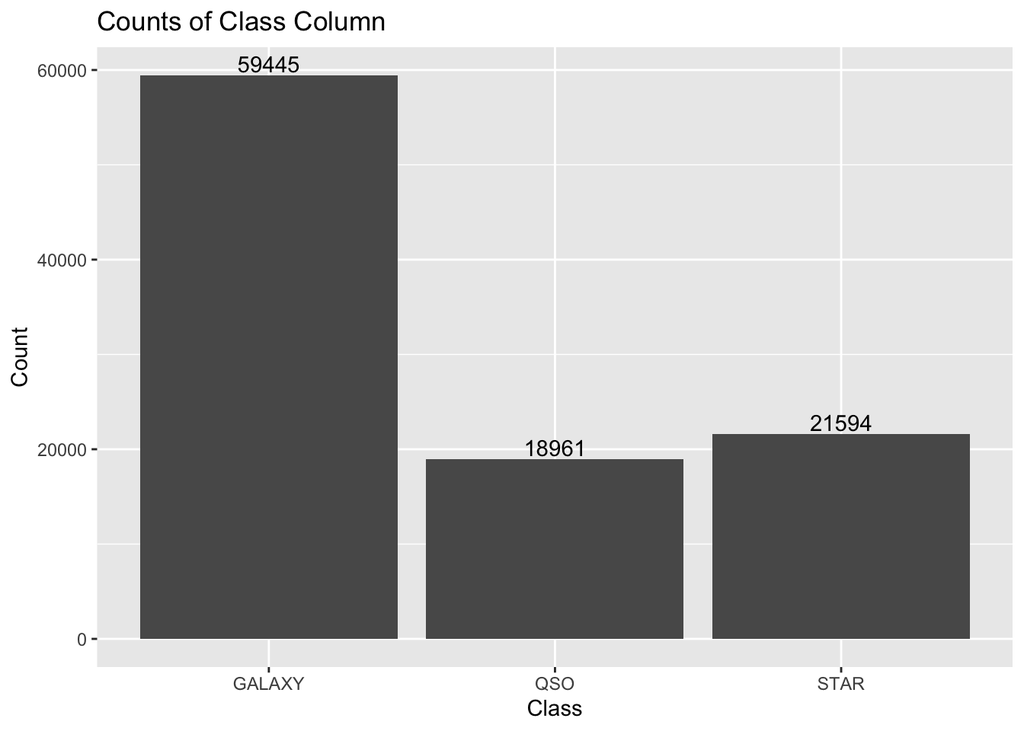

```r
ggplot(raw_df,aes(x=factor(class))) +
geom_bar() +
labs(title="Counts of Class Column", x="Class", y = "Count")+
geom_text(aes(label=..count..),stat='count', vjust=-0.2)
```

## Re-labelling `class`

The distribution of classes is quite uneven, so since we want to use binary classification we combine the two smaller classes into one larger `OTHER` class.

```r
raw_df[raw_df == 'QSO' | raw_df == 'STAR'] <- 'OTHER'
```

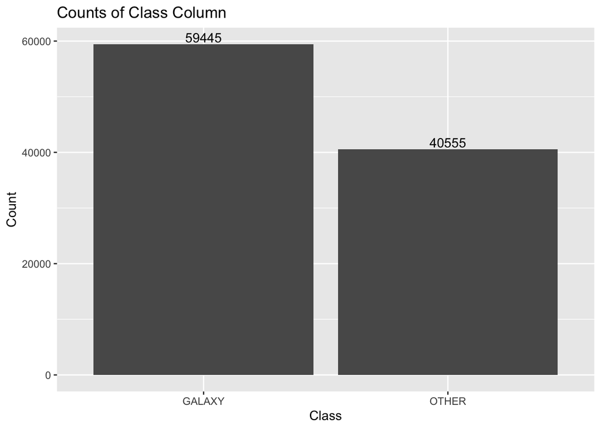

```r
ggplot(raw_df,aes(x=factor(class))) +
geom_bar() +
labs(title="Counts of Class Column", x="Class", y = "Count")+
geom_text(aes(label=..count..),stat='count', vjust=-0.2)
```

## Subsample the data

Since the class sizes are still quite uneven, we subsample the data to get even class sizes.

```r
# Filter the data by class and subsample
galaxy_df <- raw_df[raw_df$class == "GALAXY", ]
subsampled_galaxy_df <- galaxy_df[sample(nrow(galaxy_df), size = 40000, replace = FALSE),]

other_df <- raw_df[raw_df$class == "OTHER", ]
subsampled_other_df <- other_df[sample(nrow(other_df), size = 40000, replace = FALSE),]
```

```r
# Create new DataFrame
df <- rbind(subsampled_galaxy_df, subsampled_other_df)
dim(df)
```

```
## [1] 80000    18
```

Updated plot of rebalanced classes

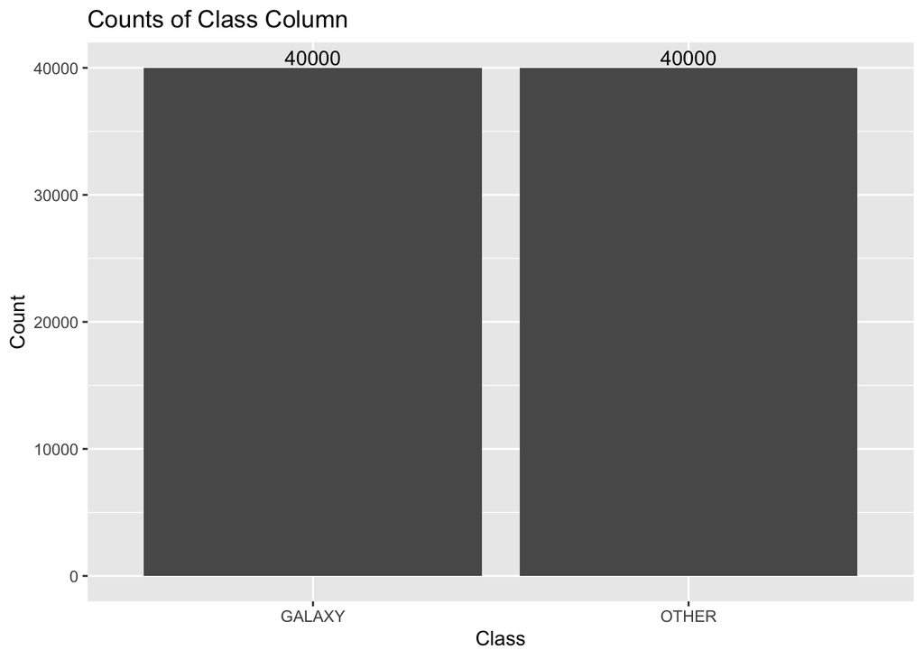

```r
ggplot(df,aes(x=factor(class))) +
geom_bar() +
labs(title="Counts of Class Column", x="Class", y = "Count")+
geom_text(aes(label=..count..),stat='count', vjust=-0.2)
```

## Summary statistics

```r
df %>%
  skimr::skim(colnames(df))
```

Data summary

| Name | Piped data |
| --- | --- |
| Number of rows | 80000 |
| Number of columns | 18 |
| _______________________ |  |
| Column type frequency: |  |
| character | 1 |
| numeric | 17 |
| ________________________ |  |
| Group variables | None |

**Variable type: character**

| skim_variable | n_missing | complete_rate | min | max | empty | n_unique | whitespace |
| --- | --- | --- | --- | --- | --- | --- | --- |
| class | 0 | 1 | 5 | 6 | 0 | 2 | 0 |

**Variable type: numeric**

| skim_variable | n_missing | complete_rate | mean | sd | p0 | p25 | p50 | p75 | p100 | hist |
| --- | --- | --- | --- | --- | --- | --- | --- | --- | --- | --- |
| obj_ID | 0 | 1 | 1.237665e+18 | 8.442763e+12 | 1.237646e+18 | 1.237659e+18 | 1.237663e+18 | 1.237668e+18 | 1.237681e+18 | ▂▅▇▃▃ |
| alpha | 0 | 1 | 1.773700e+02 | 9.691000e+01 | 1.000000e-02 | 1.264800e+02 | 1.807100e+02 | 2.343900e+02 | 3.600000e+02 | ▅▅▇▅▃ |
| delta | 0 | 1 | 2.431000e+01 | 1.971000e+01 | -1.879000e+01 | 5.190000e+00 | 2.409000e+01 | 4.026000e+01 | 8.300000e+01 | ▅▇▇▅▁ |
| u | 0 | 1 | 2.183000e+01 | 3.550000e+01 | -9.999000e+03 | 2.028000e+01 | 2.202000e+01 | 2.355000e+01 | 3.278000e+01 | ▁▁▁▁▇ |
| g | 0 | 1 | 2.044000e+01 | 3.548000e+01 | -9.999000e+03 | 1.897000e+01 | 2.100000e+01 | 2.203000e+01 | 3.160000e+01 | ▁▁▁▁▇ |
| r | 0 | 1 | 1.966000e+01 | 1.850000e+00 | 9.820000e+00 | 1.821000e+01 | 2.013000e+01 | 2.106000e+01 | 2.937000e+01 | ▁▂▇▂▁ |
| i | 0 | 1 | 1.914000e+01 | 1.770000e+00 | 9.470000e+00 | 1.782000e+01 | 1.945000e+01 | 2.049000e+01 | 3.214000e+01 | ▁▃▇▁▁ |
| z | 0 | 1 | 1.872000e+01 | 3.546000e+01 | -9.999000e+03 | 1.756000e+01 | 1.906000e+01 | 2.006000e+01 | 2.938000e+01 | ▁▁▁▁▇ |
| run_ID | 0 | 1 | 4.471120e+03 | 1.965740e+03 | 1.090000e+02 | 3.180000e+03 | 4.188000e+03 | 5.327000e+03 | 8.162000e+03 | ▂▅▇▃▃ |
| rerun_ID | 0 | 1 | 3.010000e+02 | 0.000000e+00 | 3.010000e+02 | 3.010000e+02 | 3.010000e+02 | 3.010000e+02 | 3.010000e+02 | ▁▁▇▁▁ |
| cam_col | 0 | 1 | 3.520000e+00 | 1.590000e+00 | 1.000000e+00 | 2.000000e+00 | 4.000000e+00 | 5.000000e+00 | 6.000000e+00 | ▇▅▅▅▃ |
| field_ID | 0 | 1 | 1.849900e+02 | 1.479200e+02 | 1.100000e+01 | 8.200000e+01 | 1.450000e+02 | 2.390000e+02 | 9.890000e+02 | ▇▃▁▁▁ |
| spec_obj_ID | 0 | 1 | 5.853414e+18 | 3.346775e+18 | 2.995191e+17 | 2.903780e+18 | 5.646554e+18 | 8.388148e+18 | 1.412694e+19 | ▇▇▇▅▂ |
| redshift | 0 | 1 | 6.100000e-01 | 8.000000e-01 | -1.000000e-02 | 0.000000e+00 | 4.100000e-01 | 7.700000e-01 | 7.010000e+00 | ▇▁▁▁▁ |
| plate | 0 | 1 | 5.198770e+03 | 2.972520e+03 | 2.660000e+02 | 2.579000e+03 | 5.015000e+03 | 7.450000e+03 | 1.254700e+04 | ▇▇▇▅▂ |
| MJD | 0 | 1 | 5.562661e+04 | 1.809140e+03 | 5.160800e+04 | 5.437900e+04 | 5.589300e+04 | 5.694700e+04 | 5.893200e+04 | ▃▃▇▇▅ |
| fiber_ID | 0 | 1 | 4.482000e+02 | 2.722300e+02 | 1.000000e+00 | 2.200000e+02 | 4.320000e+02 | 6.430000e+02 | 1.000000e+03 | ▇▇▇▆▅ |

# Model Recipe

## Train/Test Split

Since we have a large dataset we use 80% of the data for training.

```r
set.seed(222)
# Put 80% of the data into the training set
data_split <- initial_split(df, prop = 0.8)

# Create data frames for the two sets:
train_data <- training(data_split)
test_data  <- testing(data_split)
```

## Create our recipe

The dataset contains a lot of ID variable which do not contain useful information such as run_ID which is used to identify that specific scan.

```r
# Declare the ID variables
IDs <- c("obj_ID", "run_ID", "rerun_ID", "cam_col", "field_ID", "spec_obj_ID", "plate", "MJD", "fiber_ID")
```

Next, we create a recipe that applies some pre-processing steps.

```r
# Define our model, and exclude the ID variables
recipe <- train_data %>%
  recipe(class ~ .) %>%
  update_role(all_of(IDs), new_role = "ID") %>% # ID's not treated as predictors
  step_center(all_predictors(), -all_outcomes()) %>% # ensures mean 0
  step_scale(all_predictors(), -all_outcomes()) %>% # ensures standard deviation of 1
  prep()  # applies the pre-processing
```

A summary of which variables are treated as predictors.

```r
# Summary of the recipe
summary(recipe)
```

```
## # A tibble: 18 × 4
##    variable    type      role      source
##    <chr>       <list>    <chr>     <chr>
##  1 obj_ID      <chr [2]> ID        original
##  2 alpha       <chr [2]> predictor original
##  3 delta       <chr [2]> predictor original
##  4 u           <chr [2]> predictor original
##  5 g           <chr [2]> predictor original
##  6 r           <chr [2]> predictor original
##  7 i           <chr [2]> predictor original
##  8 z           <chr [2]> predictor original
##  9 run_ID      <chr [2]> ID        original
## 10 rerun_ID    <chr [2]> ID        original
## 11 cam_col     <chr [2]> ID        original
## 12 field_ID    <chr [2]> ID        original
## 13 spec_obj_ID <chr [2]> ID        original
## 14 redshift    <chr [2]> predictor original
## 15 plate       <chr [2]> ID        original
## 16 MJD         <chr [2]> ID        original
## 17 fiber_ID    <chr [2]> ID        original
## 18 class       <chr [3]> outcome   original
```

This can then be extracted as follows

```r
train_data <- juice(recipe) # return variables from processed training data
```

We apply the same pre-processing to the test data.

```r
test_data <- recipe %>%
  bake(test_data) # ensures that same pre-processing is used on test data.
```

# Logisitic Regression Model

Since our data set involves classification, we use logistic regression as our baseline model.

```r
# Define our logistic regression model
logistic_model <-
  logistic_reg() %>%
  set_engine("glm")
```

## Workflow

```r
# Create our workflow
logistic_wflow <-
  workflow() %>%
  add_model(logistic_model) %>%
  add_recipe(recipe)

logistic_wflow
```

```
## ══ Workflow ════════════════════════════════════════════════════════════════════
## Preprocessor: Recipe
## Model: logistic_reg()
##
## ── Preprocessor ────────────────────────────────────────────────────────────────
## 2 Recipe Steps
##
## • step_center()
## • step_scale()
##
## ── Model ───────────────────────────────────────────────────────────────────────
## Logistic Regression Model Specification (classification)
##
## Computational engine: glm
```

## Fit and explore the model

We create a a fitted model by appling the workflow.

```r
# Fit the model
logistic_fit <-
  logistic_wflow %>%
  fit(data = train_data)
```

The fitted values from our model.

```r
logistic_fit %>%
  extract_fit_parsnip() %>%
  tidy()
```

```
## # A tibble: 9 × 5
##   term         estimate std.error statistic   p.value
##   <chr>           <dbl>     <dbl>     <dbl>     <dbl>
## 1 (Intercept)   0.266      0.0120    22.1   4.20e-108
## 2 alpha        -0.00620    0.0101    -0.614 5.39e-  1
## 3 delta         0.0778     0.0100     7.77  7.84e- 15
## 4 u             1.86       0.429      4.34  1.45e-  5
## 5 g           -74.0        1.26     -58.8   0
## 6 r             1.89       0.0974    19.4   9.73e- 84
## 7 i             1.45       0.0880    16.5   6.09e- 61
## 8 z             3.51       1.18       2.98  2.91e-  3
## 9 redshift      0.222      0.0132    16.8   1.38e- 63
```

Apply this fit to our test data

```r
logistic_augment <-
  augment(logistic_fit, test_data, type = "prob")
```

## Predictions

Created predicted values and probabilities

```r
# DataFrame of prediction probabilities
pred_df <- logistic_augment %>%
  select(class, .pred_class, .pred_GALAXY)
```

```r
head(pred_df)
```

```
## # A tibble: 6 × 3
##   class  .pred_class .pred_GALAXY
##   <fct>  <fct>              <dbl>
## 1 GALAXY GALAXY             0.912
## 2 GALAXY GALAXY             0.762
## 3 GALAXY GALAXY             0.809
## 4 GALAXY GALAXY             0.543
## 5 GALAXY GALAXY             0.863
## 6 GALAXY GALAXY             0.744
```

## Evaluation of Model

The main two metrics that we will use to compare our models are ROC/AUC and accuracy.

### Evaluation metric: ROC/AUC

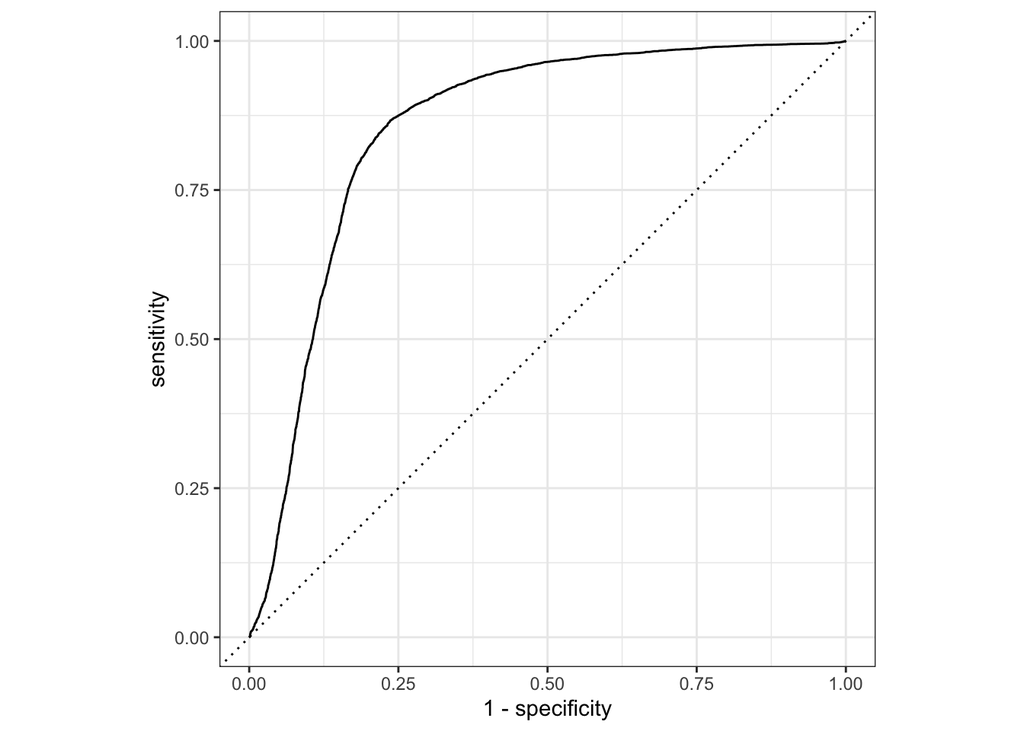

```r
logistic_augment %>%
  roc_curve(truth = as.factor(class), .pred_GALAXY) %>%
  autoplot()
```

```r
# Area Under Curve (AUC)
logistic_augment %>%
  roc_auc(truth = as.factor(class), .pred_GALAXY)
```

```
## # A tibble: 1 × 3
##   .metric .estimator .estimate
##   <chr>   <chr>          <dbl>
## 1 roc_auc binary         0.855
```

### Confusion Matrix

```r
conf_mat(pred_df, truth=class, estimate=.pred_class)
```

```
##           Truth
## Prediction GALAXY OTHER
##     GALAXY   6513  1501
##     OTHER    1578  6408
```

### Evaluation Metric: Accuracy Score

```r
logistic_accuracy <- accuracy(pred_df, as.factor(class), as.factor(.pred_class))
logistic_accuracy
```

```
## # A tibble: 1 × 3
##   .metric  .estimator .estimate
##   <chr>    <chr>          <dbl>
## 1 accuracy binary         0.808
```

For our baseline logistic regression, we get a misclassification rate of approximately 20%. This will be used compare with the later models.

# Gradient Descent (Logistic regression)

```r
X_train <- as.matrix(train_data[,c(2:8, 14)])
Y_train <- train_data$class
Y_train <- ifelse(Y_train=="GALAXY", 1,0)

X_test <- as.matrix(test_data[,c(2:8, 14)])
Y_test <- test_data$class
Y_test <- ifelse(Y_test=="GALAXY", 1,0)
```

## Gradient Descent Algorithm

```r
# Logistic regression function
logistic <- function(X, beta) {
  p <- 1 / (1 + exp(-X %*% beta))
  return(p)
}

# Gradient of the logistic regression function
grad_logistic <- function(X, y, beta) {
  n <- length(y)
  p <- logistic(X, beta)
  grad <- t(X) %*% (p - y) / n
  return(grad)
}

# Loss function of logistic
loss <- function(X, y, beta) {
  n <- length(y)
  p <- logistic(X, beta)
  loss <- -sum(y * log(p) + (1 - y) * log(1 - p)) / n
  return(loss)
}

# Implementation of the gradient descent algorithm with a variable learning rate
gradient_descent <- function(X, y, alpha, max_iter) {
  beta <- rep(0, ncol(X))
  for (i in 1:max_iter) {
    alpha_i <- alpha / sqrt(i)  # learning rate
    beta <- beta - alpha_i * grad_logistic(X, y, beta)
    if (loss(X, y, beta) == "NaN"){
      return(beta)
    }
  }
  return(beta)
}
beta_final <- gradient_descent(X_train,Y_train,10,10000)
```

## Predictions and accuracy

```r
pred <-  1/(1+exp(-(X_test %*% beta_final)))
pred <- ifelse(pred>0.5, 1,0)
grad_accuracy <- 1-sum(abs(pred-Y_test))/nrow(pred)
cat("Accuracy: ", grad_accuracy)
```

```
## Accuracy:  0.8321875
```

# Classification Tree

```r
library(tree)
#install.packages("rpart.plot")
library(rpart.plot)
tree_model <- decision_tree() %>% # We create the Classification Decision Tree
  set_engine("rpart") %>%
  set_mode("classification")

tree_workflow <- # We create a Workflow with the Tree model and our previous recipe
  workflow() %>%
  add_model(tree_model) %>%
  add_recipe(recipe)

tree_fit <-  # We fit the training data to our model
  tree_workflow %>%
  fit(data = train_data)
```

## Baseline tree

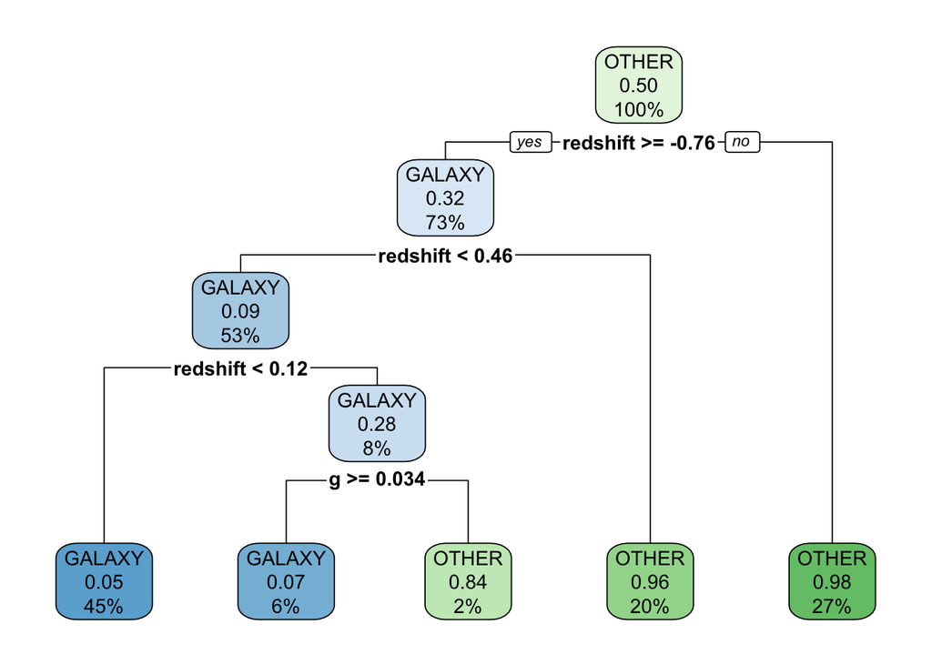

```r
tree_fit %>% # Plotting the tree through rpart package
  extract_fit_engine() %>%
  rpart.plot()
```

### Accuracy Score

```r
accuracy_untuned_tree <- augment(tree_fit, new_data = test_data) %>% # We calculate the accuracy of our predictions.
  accuracy(truth = as.factor(class), estimate = .pred_class)
accuracy_untuned_tree
```

```
## # A tibble: 1 × 3
##   .metric  .estimator .estimate
##   <chr>    <chr>          <dbl>
## 1 accuracy binary         0.953
```

## Classification Tree With Tuning

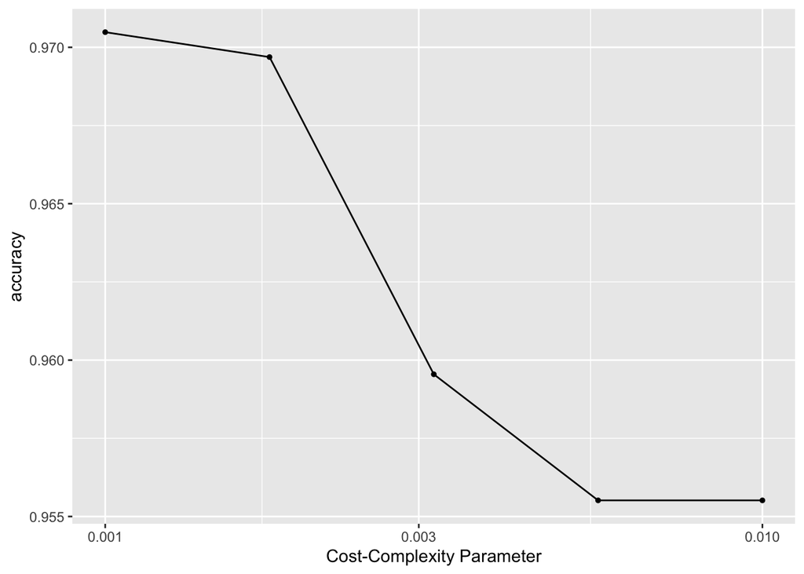

```r
folds <- vfold_cv(train_data) #We partition our data into 10 folds for CV.

tree_workflow_tuning<- # New workflow for the tuning.
  workflow() %>%
  add_model(tree_model %>% set_args(cost_complexity = tune())) %>% # We establish that the parameter we want to tune is the cost complexity of the classification tree.
  add_recipe(recipe)

#We create a parameter grid that takes 5 values from 0.001 to 0.01
param_grid <- grid_regular(cost_complexity(range = c(-3, -2)), levels = 5)

#We tune the cost complexity parameter of out decision tree for the 10 CV for the values in the parameter grid.
tuning_results <- tune_grid(
  tree_workflow_tuning,
  resamples = folds,
  grid = param_grid,
  metrics = metric_set(accuracy))

#Accuracy results for each value of the parameter
autoplot(tuning_results)
```

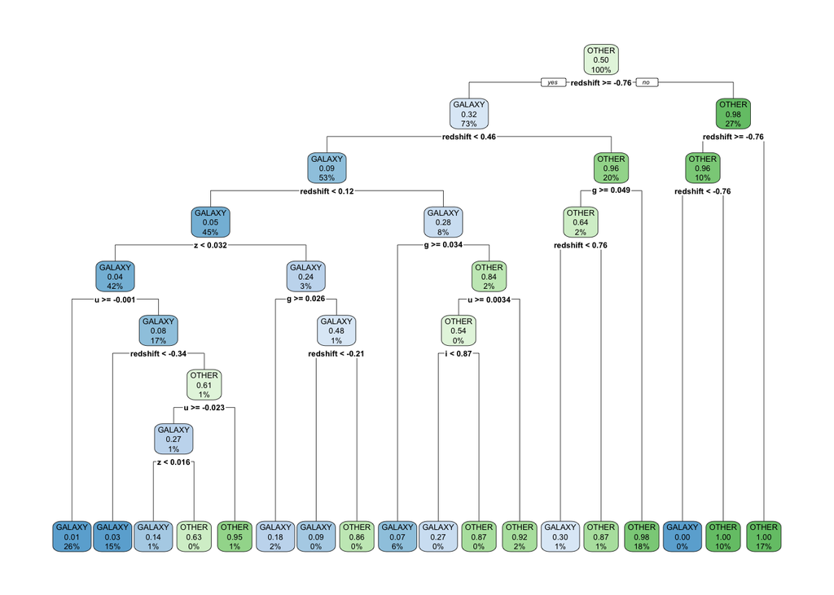

```r
best_complexity <- select_best(tuning_results) #We select the best value of the paremeter (in terms of accuracy)

final_tree <- finalize_workflow(tree_workflow_tuning, best_complexity) %>% #Refitting the decision tree with the best parameter
  fit(data = train_data)

final_tree %>% #Plotting the new tree
  extract_fit_engine() %>%
  rpart.plot()
```

### Tuned tree accuracy

```r
accuracy_tuned_tree <- augment(final_tree, new_data = test_data) %>% #Accuracy of the new tree on the test data
  accuracy(truth = as.factor(class), estimate = .pred_class)
accuracy_tuned_tree
```

```
## # A tibble: 1 × 3
##   .metric  .estimator .estimate
##   <chr>    <chr>          <dbl>
## 1 accuracy binary         0.970
```

### Confusion matrix

```r
augment(final_tree, new_data = test_data) %>% #Confusion Matrix of the final tree with the test data
  conf_mat(truth = class, estimate = .pred_class)
```

```
##           Truth
## Prediction GALAXY OTHER
##     GALAXY   7961   344
##     OTHER     130  7565
```

# Quadratic Discriminant Analysis

```r
library(discrim)
qda_model <- discrim_quad() %>% #We create the Quadratic Discriminant Analysis model
  set_mode("classification") %>%
  set_engine("MASS")

qda_workflow <- # We create a Workflow with QDA model and our previous recipe
  workflow() %>%
  add_model(qda_model) %>%
  add_recipe(recipe)

qda_fit <-  # We fit the QDA model with the training data
  qda_workflow %>%
  fit(data = train_data)

augment(qda_fit, new_data = test_data) %>% #Confusion Matrix on the test data.
  conf_mat(truth = class, estimate = .pred_class)
```

```
##           Truth
## Prediction GALAXY OTHER
##     GALAXY   7788  3627
##     OTHER     303  4282
```

```r
qda_accuracy <- augment(qda_fit, new_data = test_data) %>% # We calculate the accuracy of our predictions on the test data
  accuracy(truth = class, estimate = .pred_class)
qda_accuracy
```

```
## # A tibble: 1 × 3
##   .metric  .estimator .estimate
##   <chr>    <chr>          <dbl>
## 1 accuracy binary         0.754
```

# Linear Discriminant Analysis

```r
lda_model <- discrim_linear() %>% #We create the Linear Discriminant Analysis model
  set_mode("classification") %>%
  set_engine("MASS")

lda_workflow <-  # We create a Workflow with the LDA model and our previous recipe
  workflow() %>%
  add_model(lda_model) %>%
  add_recipe(recipe)

lda_fit <-  # We fit the LDA model with the training data
  lda_workflow %>%
  fit(data = train_data)

augment(lda_fit, new_data = test_data) %>% # Confusion Matrix on the test data.
  conf_mat(truth = class, estimate = .pred_class)
```

```
##           Truth
## Prediction GALAXY OTHER
##     GALAXY   6665  1530
##     OTHER    1426  6379
```

```r
lda_accuracy <- augment(lda_fit, new_data = test_data) %>% # We calculate the accuracy of our predictions on the test data
  accuracy(truth = class, estimate = .pred_class)
lda_accuracy
```

```
## # A tibble: 1 × 3
##   .metric  .estimator .estimate
##   <chr>    <chr>          <dbl>
## 1 accuracy binary         0.815
```

# Step 4 & 5 High-Dimensional Random Forest Model

For steps 4 & 5, we also fitted a Quadratic and Linear Discriminant analysis, but we found little improvement in comparison to the models included in this report.

## Workflow

We fit a random forest model, with the intention of achieving a lower mis-classification rate. We tune the `mtry` variable, which describes the size of the random sample of variables at each tree split.

```r
#Defines Model
rf_model <- rand_forest(mode = "classification", trees = 20, mtry = tune()) %>%
  set_engine("ranger", importance = "impurity")
```

```r
#Defines Workflow
rf_workflow <-
  workflow() %>%
  add_model(rf_model) %>% ## Add newly defined model
  add_recipe(recipe) ## Adds recipe specified earlier
```

To tune the variables, we use a 2-fold cross validation. Any larger and it takes an unreasonable amount of time to compute.

```r
#Defines cross validation
r_cv <- vfold_cv(train_data, v = 2)
```

## Fit model and examine variable importance

To visualise variable importance, which will inform interaction terms later, we fit the model to the dataframe.

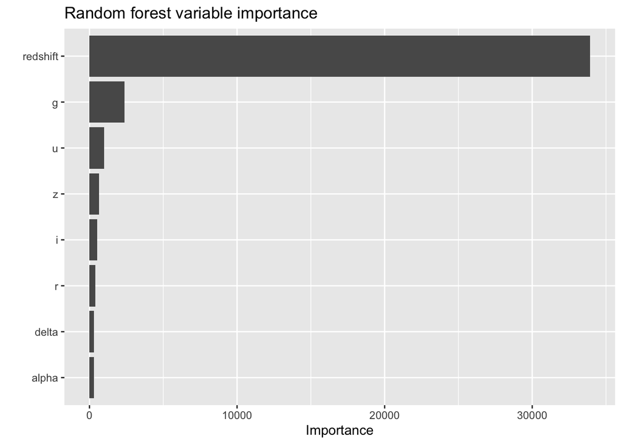

```r
#Fits model for variables importance
rf_workflow %>%
  fit(df) %>% ## Fits model
  extract_fit_parsnip() %>% ## Extracts coefficient intercepts
  vip(num_features = 8) + ## Extracts top 8
  labs(title = "Random forest variable importance") ##Labels graph
```

## Predictions

To make predictions, we fit the model with a tune grid, which will allow us to cross validate and choose the best `mtry`.

```r
# Fit the model
rf_fit <- tune_grid(
  rf_workflow, # Specifies Workflow
  r_cv, #Specifies Cross validation procedure
  metrics = metric_set(roc_auc) ## selects based on roc_auc
)
```

```
## i Creating pre-processing data to finalize unknown parameter: mtry
```

We now select the model with best results

```r
rf_best <- rf_fit %>%
  select_best()
```

And finalise the model.

```r
rf_final <-
  finalize_model(
    rf_model,
    rf_best)
rf_final
```

```
## Random Forest Model Specification (classification)
##
## Main Arguments:
##   mtry = 2
##   trees = 20
##
## Engine-Specific Arguments:
##   importance = impurity
##
## Computational engine: ranger
```

We now fit the data to the test and extract the performance statistics

```r
#Fits final model
rf_test <-
  rf_workflow %>%
  update_model(rf_final) %>%
  last_fit(data_split) %>%
  collect_metrics()
rf_test
```

```
## # A tibble: 2 × 4
##   .metric  .estimator .estimate .config
##   <chr>    <chr>          <dbl> <chr>
## 1 accuracy binary         0.975 Preprocessor1_Model1
## 2 roc_auc  binary         0.994 Preprocessor1_Model1
```

# Random Forest With Interaction Terms

In order to increase dimensionality of the data, we will add interaction terms between the variables.

## Redshift Interaction Analysis

Since redshift was the most important variable according to previous analysis, we will add one interaction for redshift, multiplied by each predictor.

```r
#Defines Recipe
red_recipe <- train_data %>%
  recipe(class ~ .) %>%
  update_role(all_of(IDs), new_role = "ID") %>%
  step_center(all_predictors(), -all_outcomes()) %>% ## Normalises
  step_scale(all_predictors(), -all_outcomes()) %>%  ## ----------
  step_interact(terms = ~ redshift:all_predictors()) %>% ## Adds interaction terms
  prep()
```

### Redshift interaction term variable importance.

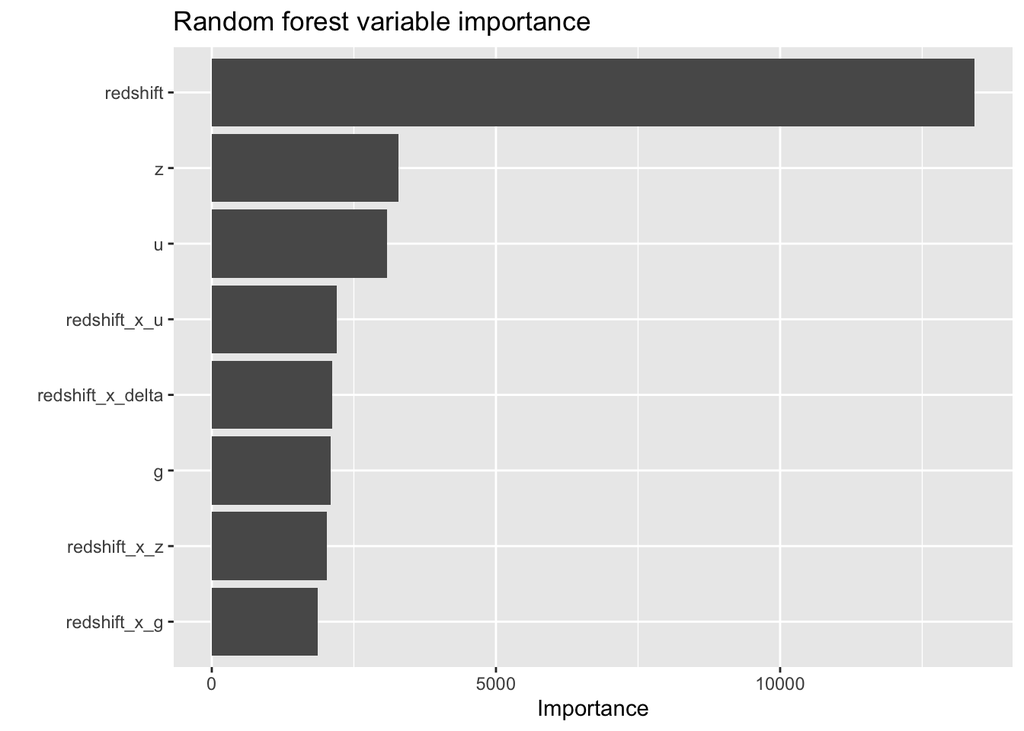

```r
#Defines Model
rf_red_model <- rand_forest(mode = "classification", mtry = 3, trees = 20) %>%
  set_engine("ranger", importance = "impurity")
#Defines Workflow
rf_red_workflow <-
  workflow() %>%
  add_model(rf_red_model) %>% #Specifies model
  add_recipe(red_recipe) #Specifies recipe
#Fits model to find variable importance as before
rf_red_workflow %>%
  fit(df) %>%
  extract_fit_parsnip() %>%
  vip(num_features = 8) +
  labs(title = "Random forest variable importance")
```

```r
# Fit the model for predictions
rf_red_fit <-
  rf_red_workflow %>%
  fit(data = train_data)
#Augments model based on test data
rf_red_augment <-
  augment(rf_red_fit, test_data, type = "prob")
#DataFrame of prediction probabilities
rf_red_pred_df <- rf_red_augment %>%
  select(class, .pred_class, .pred_GALAXY)
```

```r
#Prediction probability dataframe
rf_red_pred_df
```

```
## # A tibble: 16,000 × 3
##    class  .pred_class .pred_GALAXY
##    <fct>  <fct>              <dbl>
##  1 GALAXY GALAXY             0.95
##  2 GALAXY GALAXY             0.98
##  3 GALAXY GALAXY             0.95
##  4 GALAXY GALAXY             1
##  5 GALAXY GALAXY             1
##  6 GALAXY GALAXY             1
##  7 GALAXY GALAXY             0.993
##  8 GALAXY GALAXY             1
##  9 GALAXY GALAXY             1
## 10 GALAXY GALAXY             1
## # … with 15,990 more rows
```

### ROC/AUC for redshift interactions.

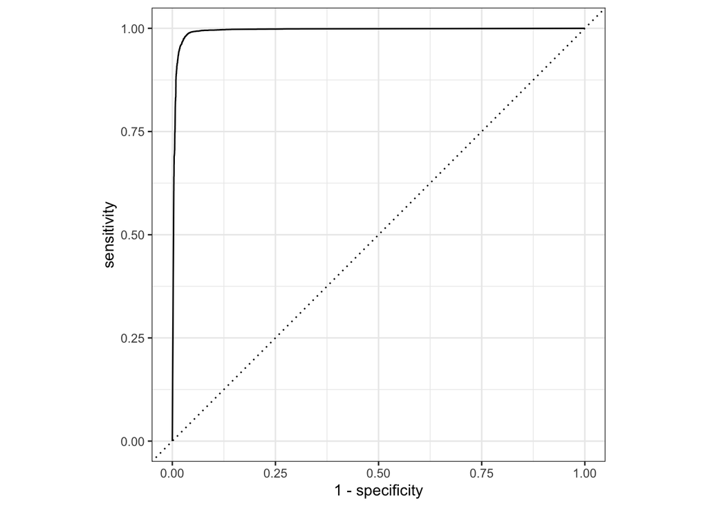

```r
#Plots ROC curve
rf_red_augment %>%
  roc_curve(truth = as.factor(class), .pred_GALAXY) %>%
  autoplot()
```

### Accuracy Score.

```r
#Calculates accuracy
rf_redshift_i <- accuracy(rf_red_pred_df, as.factor(class), as.factor(.pred_class))
rf_redshift_i
```

```
## # A tibble: 1 × 3
##   .metric  .estimator .estimate
##   <chr>    <chr>          <dbl>
## 1 accuracy binary         0.974
```

## All Predictor Interaction Analysis

Next, to increase dimensionality further, we will add all possible two-way predictor variables.

```r
#Defines new recipe
i_recipe <- train_data %>%
  recipe(class ~ .) %>%
  update_role(all_of(IDs), new_role = "ID") %>%
  step_center(all_predictors(), -all_outcomes()) %>%
  step_scale(all_predictors(), -all_outcomes()) %>%
  step_interact(terms = ~ all_predictors():all_predictors()) %>% #Adds all two-way predictor variables
  prep()
```

### All interactions variable importance

And we now run and explore the model.

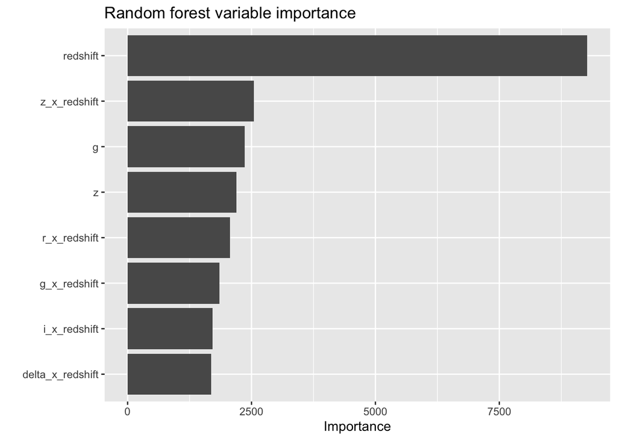

```r
#Defines Model
rf_i_model <- rand_forest(mode = "classification", mtry = 3, trees = 20) %>%
  set_engine("ranger", importance = "impurity")
#Defines Workflow
rf_i_workflow <-
  workflow() %>%
  add_model(rf_i_model) %>%
  add_recipe(i_recipe)
#Runs model for variable importance
rf_i_workflow %>%
  fit(df) %>%
  extract_fit_parsnip() %>%
  vip(num_features = 8) +
  labs(title = "Random forest variable importance")
```

```r
#Fits the model for predictions
rf_i_fit <-
  rf_i_workflow %>%
  fit(data = train_data)
#Augments model based on new data
rf_i_augment <-
  augment(rf_i_fit, test_data, type = "prob")
#DataFrame of prediction probabilities
rf_i_pred_df <- rf_i_augment %>%
  select(class, .pred_class, .pred_GALAXY)
```

```r
#Prints DataFrame of prediction probabilities
rf_i_pred_df
```

```
## # A tibble: 16,000 × 3
##    class  .pred_class .pred_GALAXY
##    <fct>  <fct>              <dbl>
##  1 GALAXY GALAXY             1
##  2 GALAXY GALAXY             0.860
##  3 GALAXY GALAXY             1
##  4 GALAXY GALAXY             1
##  5 GALAXY GALAXY             0.975
##  6 GALAXY GALAXY             0.988
##  7 GALAXY GALAXY             1
##  8 GALAXY GALAXY             0.95
##  9 GALAXY GALAXY             1
## 10 GALAXY GALAXY             1
## # … with 15,990 more rows
```

### ROC/AUC scores.

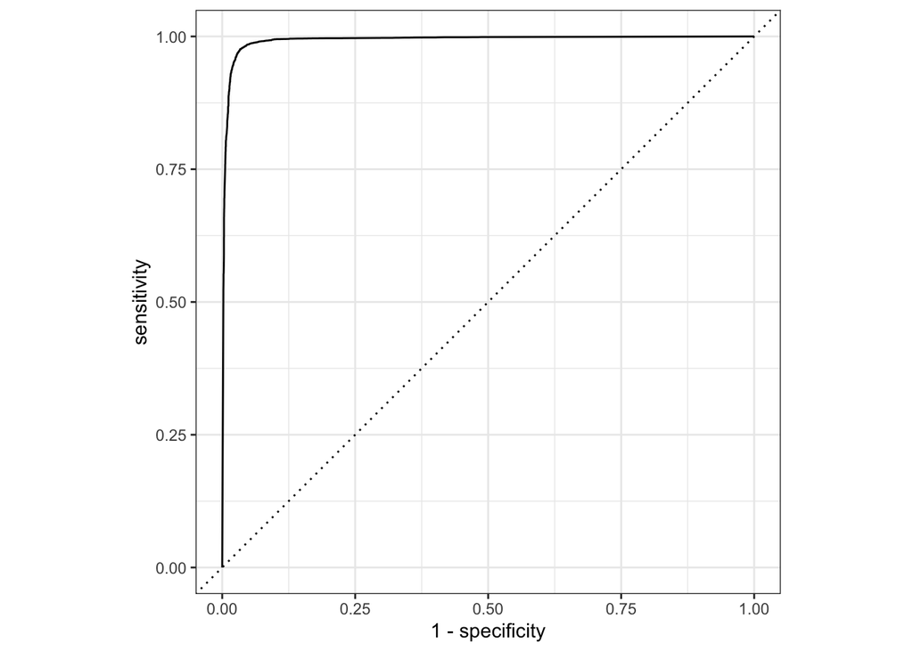

```r
#Calculates and plots ROC curve
rf_i_augment %>%
  roc_curve(truth = as.factor(class), .pred_GALAXY) %>%
  autoplot()
```

### All interactions accuracy

```r
#Calculates accuracy
rf_all_i <- accuracy(rf_i_pred_df, as.factor(class), as.factor(.pred_class))
rf_all_i
```

```
## # A tibble: 1 × 3
##   .metric  .estimator .estimate
##   <chr>    <chr>          <dbl>
## 1 accuracy binary         0.970
```

# Summary

## Model accuracy scores table.

The table below details the accuracy scores of each model we fitted:

```r
error_rates <- cbind(logistic_accuracy$.estimate[1],grad_accuracy, accuracy_untuned_tree$.estimate[1],accuracy_tuned_tree$.estimate[1],lda_accuracy$.estimate[1], qda_accuracy$.estimate[1], rf_test$.estimate[1], rf_redshift_i$.estimate[1], rf_all_i$.estimate[1])
error_rates <- round(error_rates,3)
colnames(error_rates) <- c("Logistic","Gradient Descent", "Untuned Tree","Tuned Tree","LDA","QDA", "RF no interaction", "RF redshift interaction", "RF All Interactions")
error_rates |>
  kable()
```

| Logistic | Gradient Descent | Untuned Tree | Tuned Tree | LDA | QDA | RF no interaction | RF redshift interaction | RF All Interactions |
| --- | --- | --- | --- | --- | --- | --- | --- | --- |
| 0.808 | 0.832 | 0.953 | 0.97 | 0.815 | 0.754 | 0.975 | 0.974 | 0.97 |

## Final Comments

We see that the random forest with no interaction terms achieves the best accuracy score, so we choose this as our final model.

Equipped with this, we have a highly accurate tool for predicting the type of stellar object based on the attributes in the data. Our analysis also shows that `redshift` is the biggest indicator on the class of an object.

A potential area of improvement for future would be to learn more about what the variables truly represent. While the standardisation of the data makes the units more interpretable, we are still unable to determine the true causal relationships between variables. Nonetheless, if we solely focus on predictions then the Random Forest model proves to be a useful tool.